# ML Algorithms for classification

## Use the model to predict the class/category of new data

```r
piris <- predict(miris, irisr[101:150,], type = "class")
table(irisr[101:150,5],piris)
```

```
#>             piris
#>              setosa versicolor virginica
#>   setosa         16          0         0
#>   versicolor      0         13         2
#>   virginica       0          2        17
```

## Tuning the parameters

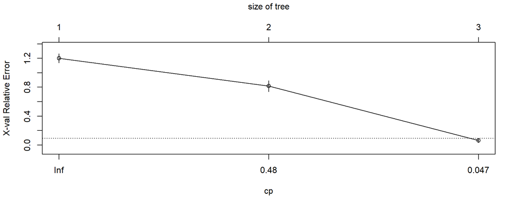

```r
plotcp(miris)
```

```r
min_cp = miris$cptable[which.min(miris$cptable[,"xerror"]),"CP"] # find best value of $cp$
min_cp
```

```
#> [1] 0.005
```

## Prune the tree using complexity parameter

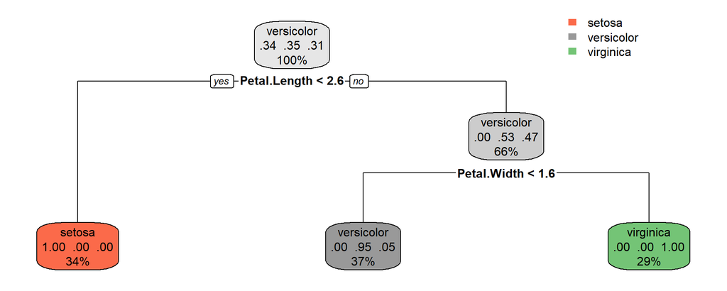

```r
# prunce tree using best cp
miris_prune = prune(miris, cp = min_cp)

rpart.plot(miris_prune)
```

## Ensemble methods - Random Forests

## What are ensemble methods in tree based modeling ?

**en-sem-ble**

A unit or group of complementary parts that contribute to a single effect, especially:

- A coordinated outfit or costume.
- A coordinated set of furniture.
- A group of musicians, singers, dancers, or actors who perform together

## Bootstrapping

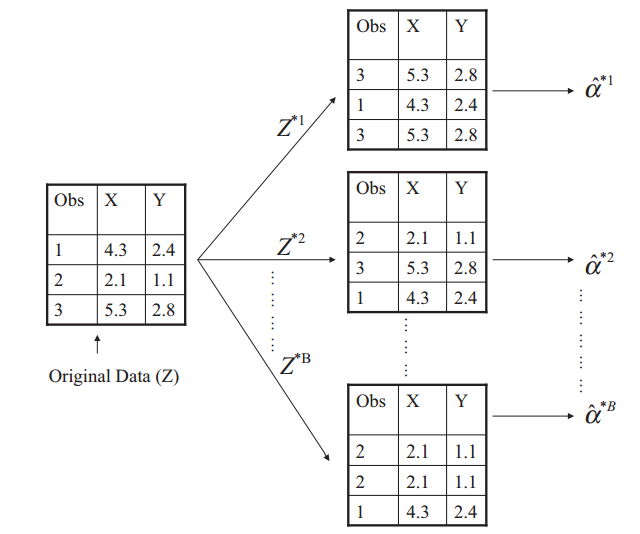

## What is bagging? how does it work?

1. **Create multiple data sets through bootstrapping:**

   Sampling is done with replacement on the original data and new datasets are formed. The new data sets can have a fraction of the columns as well as rows, which are generally hyper-parameters in a bagging model Taking row and column fractions less than 1 helps in making robust models, less prone to overfitting
2. **Build multiple classifiers:**

   Classifiers are built on each data set. Generally the same classifier is modeled on each data set and predictions are made.
3. **Combine classifiers:**

   The predictions of all the classifiers are combined using a mean, median or mode value depending on the problem at hand. The combined values are generally more robust than a single model.

## What is bagging? how does it work?

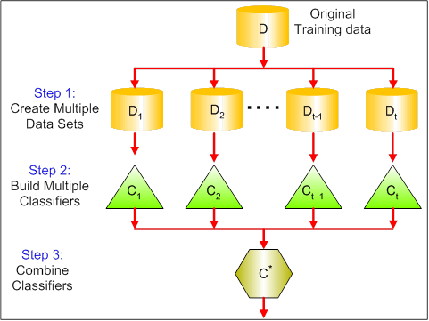

## Bagging the heart data

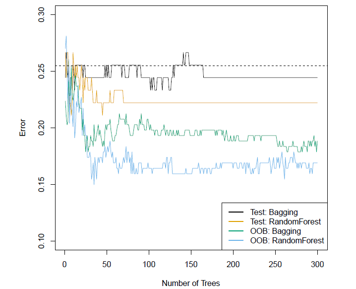

## Out-of-Bag error estimation

- It turns out that there is a very straightforward way to estimate the test error of a bagged model.
- Recall that the key to bagging is that trees are repeatedly fit to bootstrapped subsets of the observations. One can show that on average, each bagged tree makes use of around two-thirds of the observations.
- The remaining one-third of the observations not used to fit a given bagged tree are referred to as the out-of-bag (OOB) observations.
- We can predict the response for the *ith* observation using each of the trees in which that observation was OOB. This will yield around \(B/3\) predictions for the *ith* observation, which we average.
- This estimate is essentially the LOO cross-validation error for bagging, if \(B\) is large.

## What is Random Forest ? How does it work?

1. Assume number of cases in the training set is \(N\). Then, sample of these \(N\) cases is taken at random but with replacement. This sample will be the training set for growing the tree.
2. If there are \(M\) input variables, a number \(m<M\) is specified such that at each node, \(m\) variables are selected at random out of the \(M\). The best split on these \(m\) is used to split the node. The value of \(m\) is held constant while we grow the forest.
3. Each tree is grown to the largest extent possible and there is no pruning. Predict new data by aggregating the predictions of the ntree trees (i.e., majority votes for classification, average for regression).

## What is Random Forest ? How does it work?

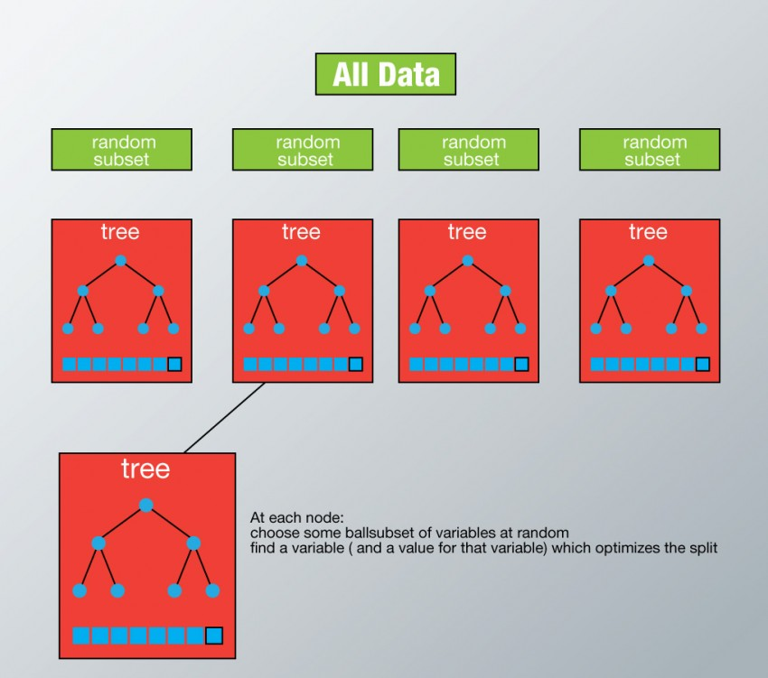

## Advantages of Random Forest

1. Random forest can solve both type of problems i.e. classification and regression and does a decent estimation at both fronts.
2. Random forest can handle large data set with higher dimensionality. Further, RF models output Importance of variable, which can be a very usefull feature (on some random data set).
3. Computation of the out-of-bag error estimate removes the need for a set aside test set.

## Ensemble methods - Gradient Boosting

## Example

We want to predict a person's age based on whether they play video games, enjoy gardening, and their preference on wearing hats. Our objective is to minimize squared error. We have these nine training samples to build our model.

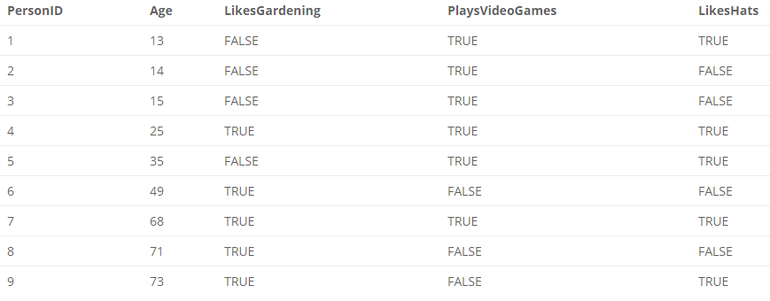

## Example

Intuitively, we might expect - The people who like gardening are probably older - The people who like video games are probably younger - `LikesHats` is probably just random noise

We can do a quick and dirty inspection of the data to check these assumptions:

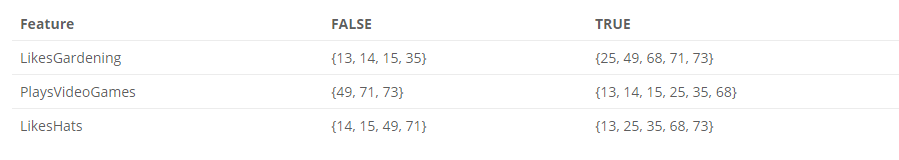

Now let's model the data with a regression tree. To start, we'll require that terminal nodes have at least three samples. With this in mind, the regression tree will make its first and last split on `LikesGardening`.

## Example

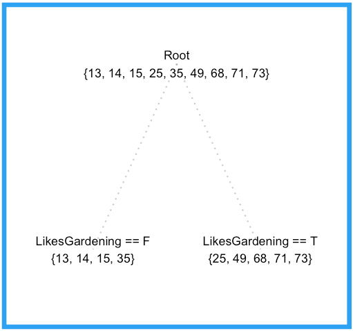

This is nice, but it's missing valuable information from the feature LikesVideoGames. Let's try letting terminal nodes have 2 samples.

## Example

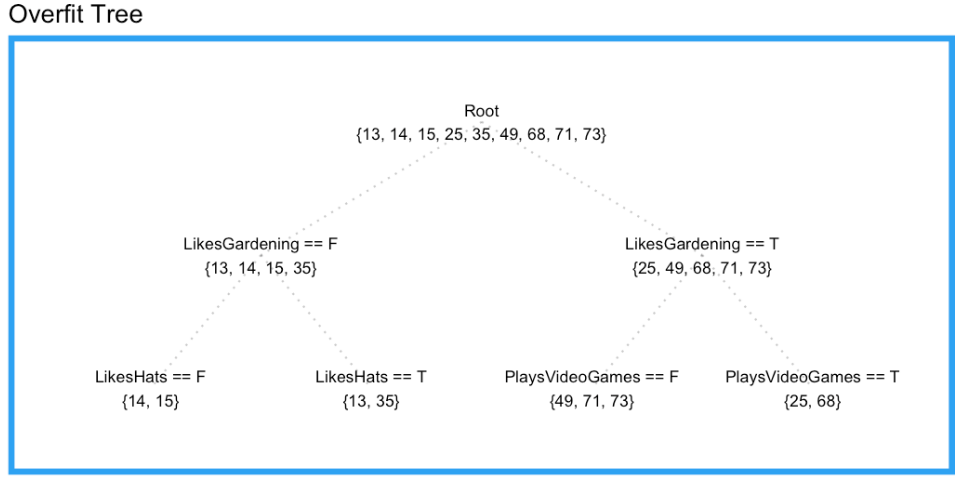

Here we pick up some information from `PlaysVideoGames` but we also pick up information from `LikesHats` - a good indication that we're overfitting and our tree is splitting random noise.

## Example

Suppose we measure the training errors from our first tree.

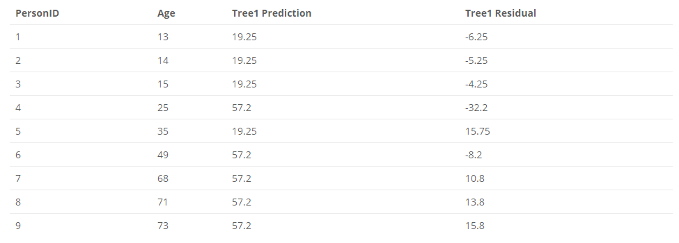

## Example

Now we can fit a second regression tree to the residuals of the first tree.

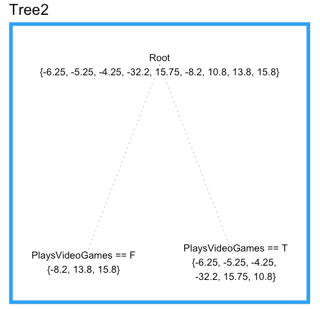

## Example

Now we can improve the predictions from our first tree by adding the "error-correcting" predictions from this tree.

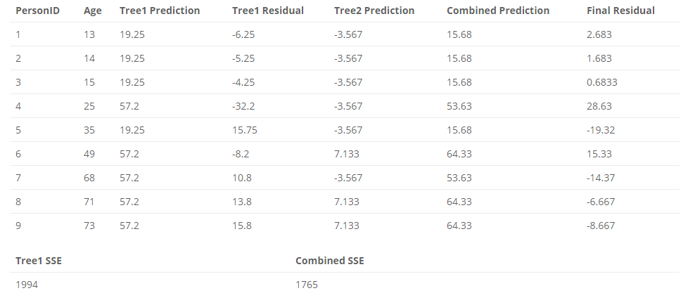

## Gradient Boosting - Theory 1

It's not hard to see how we can generalize this idea by inserting more models that correct the errors of the previous model. Specifically,

\[F(x) = F_1(x) \mapsto F_2(x) = F_1(x)+h_1(x) \dots \mapsto F_M(x) = F_{M-1}(x)+h_{M-1}(x)\] where \(F_1(x)\) is an initial model fit to \(y\)

Since we initialize the procedure by fitting \(F_1(x)\), our task at each step is to find \(h_m(x) = y - F_m(x)\).

## Gradient Boosting - Theory 2

Now we'll tweak our model to conform to most gradient boosting implementations - we'll initialize the model with a single prediction value. Since our task (for now) is to minimize squared error, we'll initialize \(F\) with the mean of the training target values. \[ F_0(x) = \underset{\gamma}{\arg\min} \sum_{i=1}^n L(y_i, \gamma) = \underset{\gamma}{\arg\min} \sum_{i=1}^n (\gamma - y_i)^2 = {\frac {1}{n}}\sum _{i=1}^{n}y_{i} \] Then we can define each subsequent \(F_m recursively\), just like before

\[ F_{m+1}(x) = F_m(x) + h_m(x) = y, for \thinspace \thinspace m \geq 0\] where \(h_m\) comes from a class of base learners \(\mathcal{H}\) (e.g. regression trees).

## Gradient Boosting - Theory 3 Gradient Descent

Let's formalize this idea using the concept of gradient descent. Consider a differentiable function we want to minimize. For example,

\[ L(x_1, x_2) = \frac{1}{2}(x_1 - 15)^2 + \frac{1}{2}(x_2 - 25)^2 \] The goal here is to find the pair \((x_1, x_2)\) that minimizes \(L\). Notice, you can interpret this function as calculating the squared error for two data points, \(15\) and \(25\) given two prediction values, \(x_1\) and \(x_2\) (but with a \(\frac{1}{2}\) multiplier to make the math work out nicely). Although we can minimize this function directly, gradient descent will let us minimize more complicated loss functions that we can't minimize directly.

## Gradient Boosting - Theory 3 Gradient Descent

Initialization Steps: Number of iteration steps M = 100 Starting point \(s^{0} = (0, 0)\) Step size \(\gamma = 0.1\)

For iteration \(m=1 to M\): 1. Calculate the gradient of \(L\) at the point \(s^{(m-1)}\) 2. "Step" in the direction of greatest descent (the negative gradient) with step size \(\gamma\). That is, \[s = s^{(m-1)} - \gamma \nabla L(s^{(m-1)})\] If \(\gamma\) is small and M is sufficiently large, \(s^{M}\) will be the location of \(L\)'s minimum value.

## Leveraging Gradient Descent - Theory 4

Now we can use gradient descent for our gradient boosting model.

The objective function we want to minimize is \(L\). Our starting point is \(F_0(x)\).

For iteration \(m = 1\), we compute the gradient of \(L\) with respect to \(F_0(x)\).

Then we fit a weak learner to the gradient components.

In the case of a regression tree, leaf nodes produce an average gradient among samples with similar features.

For each leaf, we step in the direction of the average gradient (using line search to determine the step magnitude). The result is \(F_1\).

Then we can repeat the process until we have \(F_M\).

## Leveraging Gradient Descent - Theory 4

Initialize the model with a constant value: \[F_0(x) = \underset{\gamma}{\arg\min} \sum_{i=1}^n L(y_i, \gamma)\]

For m = 1 to M:

- Compute pseudo residuals, \(r_{im} = -\left[\frac{\partial L(y_i, F(x_i))}{\partial F(x_i)}\right]_{F(x)=F_{m-1}(x)} \quad \mbox{for } i=1,\ldots,n.\)
- Fit base learner, \(h_{m}(x)\) to pseudo residuals
- Compute step magnitude multiplier \(\gamma_m\).
- Update \(F_m(x) = F_{m-1}(x) + \gamma_m h_m(x)\)

## Leveraging Gradient Descent - Theory 4

In case you want to check your understanding so far, our current gradient boosting applied to our sample problem for squared error yields the following results.

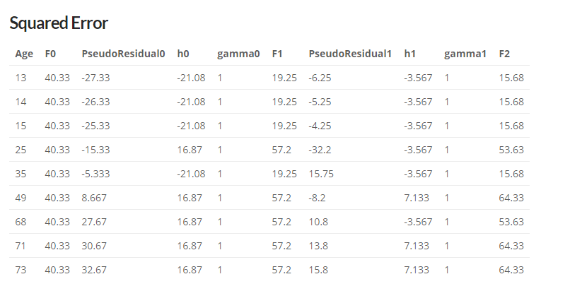

## Leveraging Gradient Descent - Theory 4

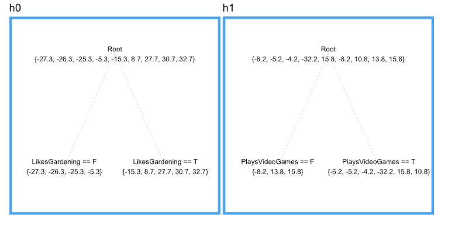

## Gradient Boosting in Practice

Incredibly effective in practice.

Perhaps the most popular implementation, `XGBoost`, is used in a number of winning Kaggle solutions. `XGBoost` employs a number of tricks that make it faster and more accurate than traditional gradient boosting (particularly 2nd-order gradient descent).

With that said, a new competitor, `LightGBM` from Microsoft, is gaining significant traction.

What else can it do? Although the example above presented gradient boosting as a regression model, it's also very effective as a classification and ranking model.

As long as you have a differentiable loss function for the algorithm to minimize, you're good to go.

## References

[An Introduction to Recursive Partitioning Using the rpart Routines](http://bit.ly/2oQiao8) - Details of the rpart package. rpart.plot Package - Detailed manual on plotting with rpart using the rpart.plot package.

## Thank you!

- Slides: http://bit.ly/2q9NPSU
- GitHub: https://github.com/trefoil-ml
- Twitter: https://twitter.com/trefoilML
- Email: info@tridata.nl or hzmarrou@gmail.com